# 431 Class 18

Thomas E. Love, Ph.D.

2026-10-27

## Today’s Agenda

Two-Factor (Two-Way) Analysis of Variance

- The importance of interaction
- Interpreting ANOVA output
- What are the key model checks for ANOVA?
- Comparing Model Performance Indices
- What if we add a covariate?

## Today’s Packages

```r
knitr::opts_chunk$set(comment = NA)

library(googlesheets4)
library(gt)
library(janitor)
library(mice)
library(naniar)
library(easystats)
library(tidyverse)

theme_set(theme_bw())
```

## Favorite Movies Data

```r
gs4_deauth() # indicates to Google Drive that you're reading a public file

url_movies <- "https://docs.google.com/spreadsheets/d/1LJdlS1JUYQqJidrnkJ5OmFZr009g25oiZkvtZXhXXlc"
## this is movies_2026-10-13 from our shared drive

mov_raw <- read_sheet(url_movies, na = c("", "NA"))
```

```
✔ Reading from "movies_2026-10-13".
```

```
✔ Range 'movies_2026-10-13'.
```

```r
dim(mov_raw)
```

```
[1] 282  97
```

## Describing Today’s Variables

- Favorite movies from students in 2020-2026

| Variable | Description |
| --- | --- |
| `mov_id` | M-xxx code to identify movie |
| `metascore` | **outcome**: critic rating (0 to 100) pulled from [Metacritic](https://www.metacritic.com/) |
| `drama` | Is drama one of the [IMDB](https://www.imdb.com/) genres for this movie? (1 = yes, 0 = no) |
| `comedy` | Is comedy one of the [IMDB](https://www.imdb.com/) genres for this movie? (1 = yes, 0 = no) |
| `bacon_s1` | Bacon number (from [Oracle of Bacon](https://oracleofbacon.org/)) for movie’s first listed star |
| `rt_audience` | Audience rating (0 to 100) from [Rotten Tomatoes](https://www.rottentomatoes.com/) |
| `movie` | Movie Name to identify movie |

- Bacon number = # of movies it takes to connect the star to Kevin Bacon.
  - Bacon = 1: star has been in a movie with Kevin Bacon.
  - None of our 282 movies feature Kevin Bacon, as it turns out.

## Today’s analytic data

```r
mov_18 <- mov_raw |>
  select(mov_id, metascore, drama, comedy, bacon_s1, rt_audience, movie) |>
  mutate(drama = factor(drama), comedy = factor(comedy),
         bacon_s1 = factor(bacon_s1), movie = as.character(movie))

mov_18 |> gt_preview(top_n = 5, bottom_n = 1, incl_rownums = TRUE) |>
  tab_options(table.font.size = 24)
```

|  | mov_id | metascore | drama | comedy | bacon_s1 | rt_audience | movie |
| --- | --- | --- | --- | --- | --- | --- | --- |
| 1 | M-001 | 67 | 1 | 1 | 3 | 93 | 3 Idiots |
| 2 | M-002 | 93 | 1 | 0 | 2 | 92 | 8 1/2 |
| 3 | M-003 | 70 | 1 | 1 | 2 | 69 | 10 Things I Hate About You |
| 4 | M-004 | 83 | 1 | 1 | 2 | 74 | 20th Century Women |
| 5 | M-005 | 52 | 1 | 0 | 2 | 89 | 300 |
| 6..281 |  |  |  |  |  |  |  |
| 282 | M-282 | 61 | 0 | 1 | 2 | 80 | Zoolander |

## Dealing with missing values

```r
miss_var_summary(mov_18) |> filter(n_miss > 0) |>
  gt() |> tab_options(table.font.size = 20)
```

| variable | n_miss | pct_miss |
| --- | --- | --- |
| metascore | 18 | 6.38 |
| rt_audience | 3 | 1.06 |
| bacon_s1 | 2 | 0.709 |

```r
miss_case_table(mov_18) |>
  gt() |> tab_options(table.font.size = 20)
```

| n_miss_in_case | n_cases | pct_cases |
| --- | --- | --- |
| 0 | 264 | 93.6170213 |
| 1 | 15 | 5.3191489 |
| 2 | 1 | 0.3546099 |
| 3 | 2 | 0.7092199 |

## Can we assume MCAR?

Can we use data to assess whether assuming **MCAR** is reasonable?

```r
mov_18 |> mcar_test()
```

```
# A tibble: 1 × 4
  statistic    df  p.value missing.patterns
      <dbl> <dbl>    <dbl>            <int>
1      41.3    15 0.000284                4
```

With a high chi-square statistic and tiny *p* value from the [Little (1988) test](https://www.tandfonline.com/doi/abs/10.1080/01621459.1988.10478722), we conclude that there is essentially no evidence that the data are missing completely at random.

- So we should be highly motivated to impute.

## Today’s Imputation Strategy

Today, we’ll assume **MAR** and impute all missing values, including `metascore`, which will be our outcome.

- Another approach we’ll often use would be to impute everything **except for** the outcome.

How many imputations should we consider running?

```r
mov_18 |> pct_miss_case()
```

```
[1] 6.382979
```

### Building 10 imputations

```r
set.seed(20261027)

mov_18_mice10 <- mice(mov_18, m = 10, printFlag = FALSE)
```

## Two Primary Analytic Data Sets

```r
## complete cases
mov_cc <- mov_18 |> drop_na()
dim(mov_cc)
```

```
[1] 264   7
```

```r
n_miss(mov_cc)
```

```
[1] 0
```

### Selecting a single imputation

```r
## arbitrarily chose to look at the third imputation of 10
mov_i3 <- complete(mov_18_mice10, 3) |> tibble()

dim(mov_i3)
```

```
[1] 282   7
```

```r
n_miss(mov_i3)
```

```
[1] 0
```

## Example 1

Suppose we want to simultaneously understand the impacts of two factors on `metascore`, specifically:

- `drama` (1 or 0)
- `comedy` (1 or 0), and

and it is possible that the impact of `comedy` on `metascore` may depend on whether the movie is also a `drama` (i.e. `comedy` and `drama` may **interact**.)

- For a start, we’ll analyze the data with **complete cases**.

## Looking at our two factors

```r
mov_cc |> count(drama, comedy) |>
  gt() |> tab_options(table.font.size = 24) |>
  opt_stylize(style = 6, color = "blue", add_row_striping = TRUE)
```

| drama | comedy | n |
| --- | --- | --- |
| 0 | 0 | 57 |
| 0 | 1 | 56 |
| 1 | 0 | 104 |
| 1 | 1 | 47 |

## An interaction plot is a plot of means.

Calculate and store the group means.

```r
ex1_means <- mov_cc |>
  group_by(comedy, drama) |>
  summarize(n = n(), mean_metascore = mean(metascore))

ex1_means
```

```
# A tibble: 4 × 4
# Groups:   comedy [2]
  comedy drama     n mean_metascore
  <fct>  <fct> <int>          <dbl>
1 0      0        57           70.5
2 0      1       104           74.8
3 1      0        56           65.8
4 1      1        47           68.2
```

## How strong is the interaction?

Now, we’ll plot these means, and look for a substantial interaction (non-parallel lines.)

```r
ggplot(ex1_means, aes(x = drama, y = mean_metascore)) +
  geom_line(aes(group = comedy, color = comedy)) +
  geom_point(aes(color = comedy)) +
  scale_color_material() +
  labs(title = "Example 1 Interaction Plot",
       subtitle = "Do we see substantially non-parallel lines?",
       y = "Metascore (0-100)",
       x = "Drama (1 = yes, 0 = no)",
       color = "Comedy",
       caption = "Complete Cases (n = 264 movies)")
```

## How strong is the interaction?

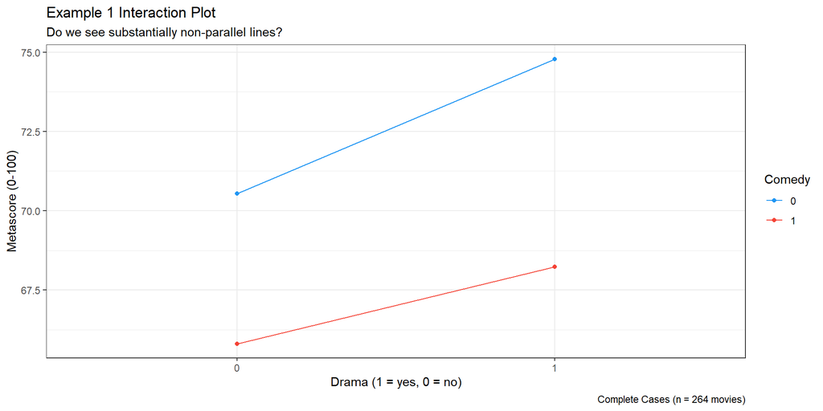

## Two-Way ANOVA without interaction

This model predicts our outcome (`metascore`) using the two factors as main effects only (with no interaction.)

```r
mainfx <- lm(metascore ~ drama + comedy, data = mov_cc)

mainfx
```

```
Call:
lm(formula = metascore ~ drama + comedy, data = mov_cc)

Coefficients:
(Intercept)       drama1      comedy1
     71.024        3.501       -5.709
```

$$metascore = 71.024 + 3.501 (drama = 1) - 5.709 (comedy = 1)$$

## Interpret the drama estimate: 3.50?

```r
model_parameters(mainfx, ci = 0.90, pretty_names = FALSE)
```

```
Parameter   | Coefficient |   SE |         90% CI | t(261) |      p
-------------------------------------------------------------------
(Intercept) |       71.02 | 1.77 | [68.10, 73.95] |  40.09 | < .001
drama1      |        3.50 | 1.97 | [ 0.24,  6.76] |   1.77 | 0.077
comedy1     |       -5.71 | 2.00 | [-9.02, -2.40] |  -2.85 | 0.005
```

If we have two movies with the same `comedy` status, but only one has a `drama` = 1, then **on average** the dramatic movie will have a metascore that is 3.50 points higher than the movie which is not a drama, according to our `mainfx` model.

## Interpret the estimate: -5.71?

```r
model_parameters(mainfx, ci = 0.90, pretty_names = FALSE)
```

```
Parameter   | Coefficient |   SE |         90% CI | t(261) |      p
-------------------------------------------------------------------
(Intercept) |       71.02 | 1.77 | [68.10, 73.95] |  40.09 | < .001
drama1      |        3.50 | 1.97 | [ 0.24,  6.76] |   1.77 | 0.077
comedy1     |       -5.71 | 2.00 | [-9.02, -2.40] |  -2.85 | 0.005
```

Our `mainfx` model estimates that if we have two movies with the same drama status, but one is a comedy and the other is not, then **on average** the comedy will have a metascore that is 5.71 points lower than the movie which is not a comedy.

## Interpret the intercept term?

```r
model_parameters(mainfx, ci = 0.90, pretty_names = FALSE)
```

```
Parameter   | Coefficient |   SE |         90% CI | t(261) |      p
-------------------------------------------------------------------
(Intercept) |       71.02 | 1.77 | [68.10, 73.95] |  40.09 | < .001
drama1      |        3.50 | 1.97 | [ 0.24,  6.76] |   1.77 | 0.077
comedy1     |       -5.71 | 2.00 | [-9.02, -2.40] |  -2.85 | 0.005
```

71.02 is the intercept. It’s the `mainfx` model’s estimate of the mean of `metascore` across all movies where both `drama` is 0 and `comedy` is 0.

## ANOVA table for `mainfx`

```r
anova(mainfx)
```

```
Analysis of Variance Table

Response: metascore
           Df Sum Sq Mean Sq F value  Pr(>F)
drama       1   1340 1340.21  5.5099 0.01966 *
comedy      1   1976 1975.76  8.1228 0.00472 **
Residuals 261  63484  243.24
---
Signif. codes:  0 '***' 0.001 '**' 0.01 '*' 0.05 '.' 0.1 ' ' 1
```

### % of Total SS explained by the two factors?

- Total SS = 1340 + 1976 + 63484 = 66800
- So % explained = (1340 + 1976) / 66800 = 0.0496, or 4.96%

## Model `mainfx` and its assumptions

- `mainfx` is a “main effects only” model. It assumes there is zero interaction between `drama` and `comedy` in predicting `metascore`.
- Like any ANOVA model, `mainfx` makes the usual linear model assumptions (linearity, constant variance, Normality)
  - Focus: posterior predictive check, and Normal Q-Q plot of residuals<sup>1</sup>.
[^1]: The assessment of linearity and non-constant variance used by `check_model()` are best used when we have at least one quantitative predictor in our model.

## Checking model `mainfx`

```r
set.seed(20264311)
check_model(mainfx, check = c("pp_check", "qq"), detrend = FALSE)
```

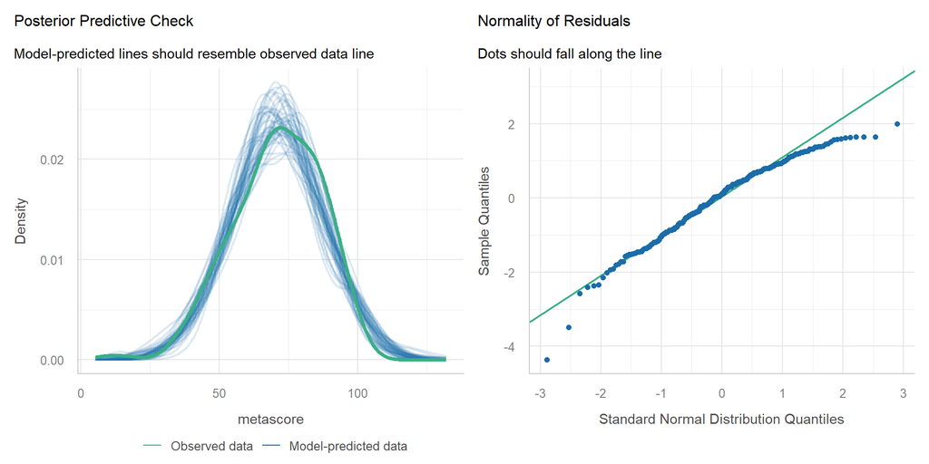

## Interaction Plot, again

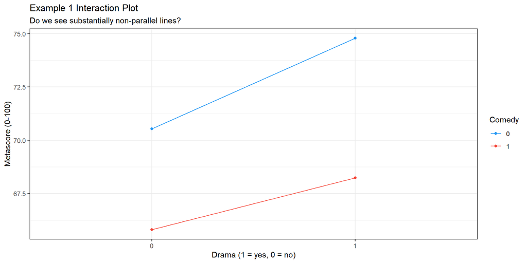

## Two-Way ANOVA with Interaction

Fit the linear model, including an interaction (`*`) between our factors.

```r
withint <- lm(metascore ~ drama * comedy, data = mov_cc)

withint
```

```
Call:
lm(formula = metascore ~ drama * comedy, data = mov_cc)

Coefficients:
   (Intercept)          drama1         comedy1  drama1:comedy1
        70.544           4.245          -4.740          -1.814
```

## `withint` model equation?

$$metascore = 70.544 + 4.245 (drama = 1) - 4.740 (comedy = 1) \\
- 1.814 (drama = 1) \times (comedy = 1)$$

| `drama` | `comedy` | Estimated `metascore` |
| --- | --- | --- |
| 0 | 0 | 70.544 |
| 0 | 1 | 70.544 - 4.740 = 65.804 |
| 1 | 0 | 70.544 + 4.245 = 74.789 |
| 1 | 1 | 70.544 + 4.245 - 4.740 - 1.814 = 68.235 |

## Effect of `comedy` = 1?

| Est. `metascore` | `comedy` = 0 | `comedy` = 1 |
| --- | --- | --- |
| `drama` = 0 | 70.544 | 65.804 |
| `drama` = 1 | 74.789 | 68.235 |

- If `drama` = 0, difference between `comedy` = 0 and `comedy` = 1 estimates is 4.740 (70.544 - 65.804)
- If `drama` = 1, difference between `comedy` = 0 and `comedy` = 1 estimates is 6.554 (74.789 - 68.235)
- So the model’s estimated effect of `comedy` **depends** on `drama`.

## Effect of `drama` = 1?

| Est. `metascore` | `comedy` = 0 | `comedy` = 1 |
| --- | --- | --- |
| `drama` = 0 | 70.544 | 65.804 |
| `drama` = 1 | 74.789 | 68.235 |

- If `comedy` = 0, difference between `drama` = 1 and `drama` = 0 estimates is 4.245 (74.789 - 70.544)
- If `comedy` = 1, difference between `drama` = 1 and `drama` = 0 estimates is 2.431 (68.235 - 65.804)
- So the model’s estimated effect of `drama` **depends** on `comedy`.

## ANOVA table for `withint` model

```r
anova(withint)
```

```
Analysis of Variance Table

Response: metascore
              Df Sum Sq Mean Sq F value   Pr(>F)
drama          1   1340 1340.21  5.4931 0.019845 *
comedy         1   1976 1975.76  8.0980 0.004784 **
drama:comedy   1     50   49.64  0.2035 0.652305
Residuals    260  63435  243.98
---
Signif. codes:  0 '***' 0.001 '**' 0.01 '*' 0.05 '.' 0.1 ' ' 1
```

- Total SS = 1340 + 1976 + 50 + 63435 = 66801
- % explained = (1340 + 1976 + 50) / 66801 = 0.0504, or 5.04%
- Is this a big improvement over the `mainfx` model?

## Checking model `withint`

```r
set.seed(20264312)
check_model(withint, check = c("pp_check", "qq"), detrend = FALSE)
```

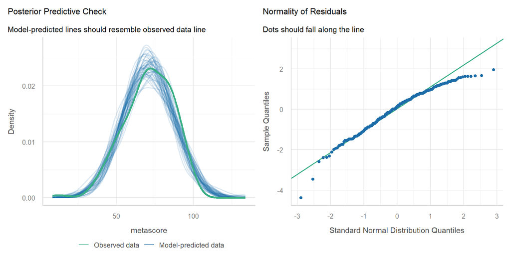

## Compare performance of our two models?

```r
compare_performance(mainfx, withint, rank = TRUE)
```

```
# Comparison of Model Performance Indices

Name    | Model |    R2 | R2 (adj.) |   RMSE |  Sigma | AIC weights
-------------------------------------------------------------------
mainfx  |    lm | 0.050 |     0.042 | 15.507 | 15.596 |       0.710
withint |    lm | 0.050 |     0.039 | 15.501 | 15.620 |       0.290

Name    | AICc weights | BIC weights | Performance-Score
--------------------------------------------------------
mainfx  |        0.718 |       0.936 |            71.43%
withint |        0.282 |       0.064 |            28.57%
```

## Plot to compare performance indicators

```r
plot(compare_performance(mainfx, withint))
```

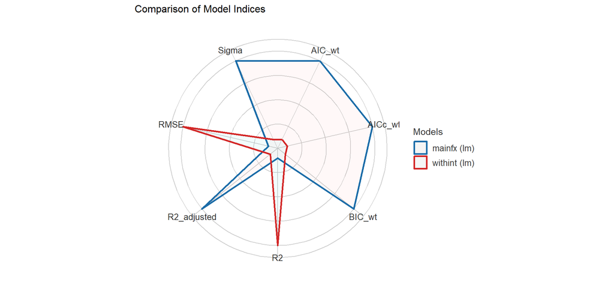

## Do we have a substantial interaction?

- Interaction plot shows essentially parallel lines.
- % of variation explained by the interaction term is less than 0.1% of the variation in `meta_score`, overall.
- p value for the interaction term is pretty large ($p$ = 0.65)
- Is there a substantial improvement in the fit with the interaction?
  - Only in terms of raw $R^2$ and RMSE.

## What if we used the single imputation instead?

**In this example, nothing important changes** as it turns out.

- We’ll largely skip through the slides from here to the standing break, but you can review them on your own to see that nothing substantial has changed as a result of including a few more movies.
- Doesn’t mean that nothing *could have* changed, but not much did, in this case.

## Table of Means?

```r
ex1_means_i <- mov_i3 |>
  group_by(comedy, drama) |>
  summarize(n = n(), mean_metascore = mean(metascore))

ex1_means_i
```

```
# A tibble: 4 × 4
# Groups:   comedy [2]
  comedy drama     n mean_metascore
  <fct>  <fct> <int>          <dbl>
1 0      0        57           70.5
2 0      1       112           75.3
3 1      0        58           65.2
4 1      1        55           66.7
```

## How strong is the interaction?

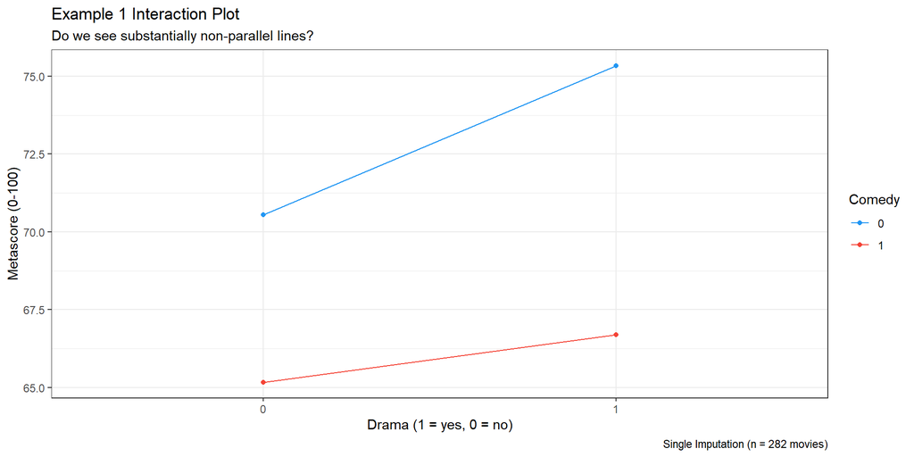

## Two-Way ANOVA without interaction

```r
mainfx_i <- lm(metascore ~ drama + comedy, data = mov_i3)

mainfx_i
```

```
Call:
lm(formula = metascore ~ drama + comedy, data = mov_i3)

Coefficients:
(Intercept)       drama1      comedy1
     71.473        3.394       -7.213
```

Remember, the model with complete cases was:

$$metascore = 71.024 + 3.501 (drama = 1) - 5.709 (comedy = 1)$$

## ANOVA table for `mainfx_i`

```r
anova(mainfx_i)
```

```
Analysis of Variance Table

Response: metascore
           Df Sum Sq Mean Sq F value    Pr(>F)
drama       1   1477  1476.5  6.0478 0.0145307 *
comedy      1   3415  3414.8 13.9873 0.0002234 ***
Residuals 279  68115   244.1
---
Signif. codes:  0 '***' 0.001 '**' 0.01 '*' 0.05 '.' 0.1 ' ' 1
```

### % of Total SS explained by the two factors?

- Total SS = 1477 + 3415 + 68115 = 73007
- So % explained = (1477 + 3415) / 73007 = 0.0670, or 6.70%

## Checking model `mainfx_i`

```r
set.seed(20264313)
check_model(mainfx_i, check = c("pp_check", "qq"), detrend = FALSE)
```

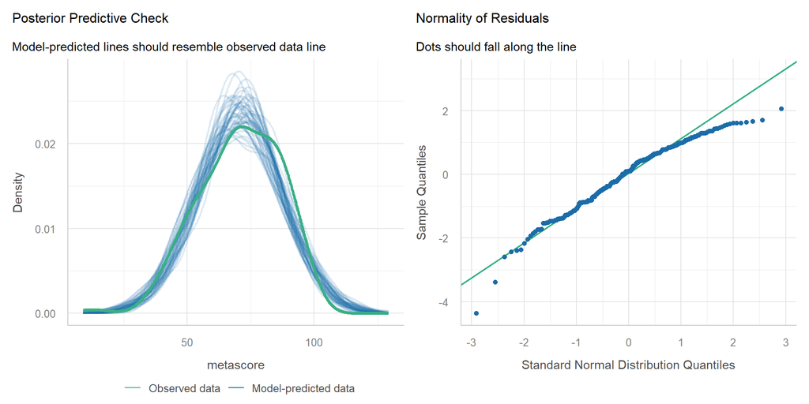

## Two-Way ANOVA with Interaction

```r
withint_i <- lm(metascore ~ drama * comedy, data = mov_i3)

withint_i
```

```
Call:
lm(formula = metascore ~ drama * comedy, data = mov_i3)

Coefficients:
   (Intercept)          drama1         comedy1  drama1:comedy1
        70.544           4.795          -5.371          -3.277
```

With complete cases, the model was:

$$metascore = 70.544 + 4.245 (drama = 1) - 4.740 (comedy = 1) \\
- 1.814 (drama = 1) \times (comedy = 1)$$

## ANOVA table for `withint_i` model

```
Analysis of Variance Table

Response: metascore
              Df Sum Sq Mean Sq F value    Pr(>F)
drama          1   1477  1476.5  6.0415 0.0145836 *
comedy         1   3415  3414.8 13.9727 0.0002252 ***
drama:comedy   1    173   173.5  0.7099 0.4002075
Residuals    278  67941   244.4
---
Signif. codes:  0 '***' 0.001 '**' 0.01 '*' 0.05 '.' 0.1 ' ' 1
```

- Total SS = 1477 + 3415 + 173 + 67941 = 73006
- % explained = (1477 + 3415 + 173) / 73006 = 0.0693, or 6.93%
- Again, no big improvement over the `mainfx` model

## Checking model `withint_i`

```r
set.seed(20264314)
check_model(withint_i, check = c("pp_check", "qq"), detrend = FALSE)
```

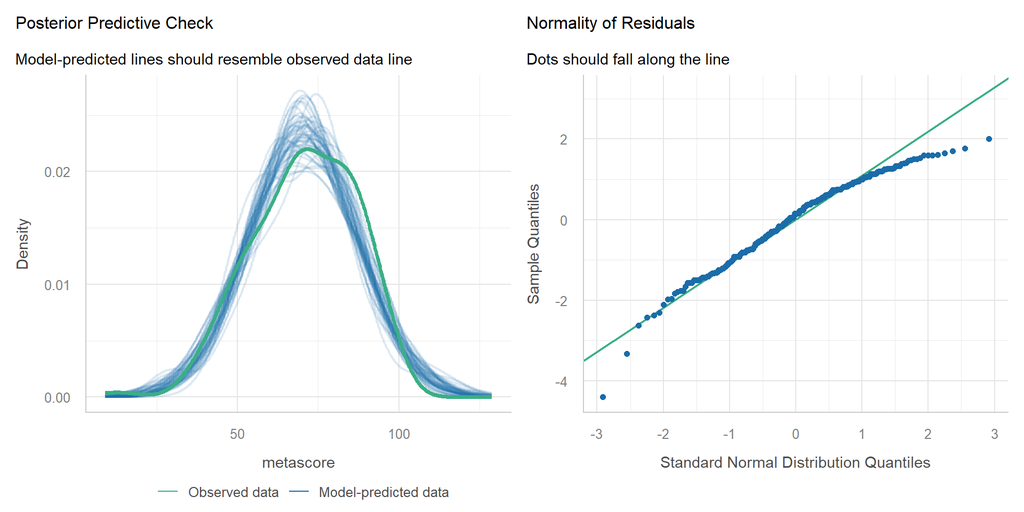

## Plot to compare performance indicators

```r
plot(compare_performance(mainfx_i, withint_i))
```

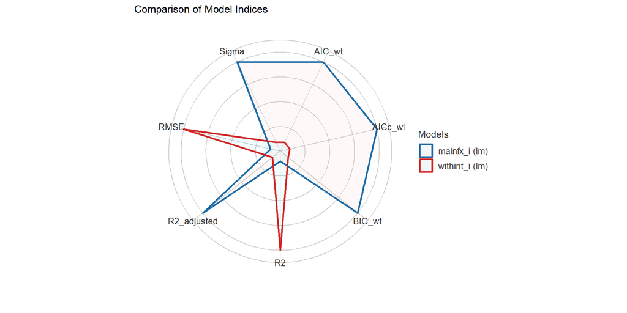

## Do we have a substantial interaction?

No change in any of this.

- Interaction plot shows essentially parallel lines.
- % of variation explained by the interaction term is less than 0.3% of the variation in `metascore`, overall.
- p value for the interaction term is pretty large ($p$ = 0.40)
- Substantial improvement in the fit with the interaction?
  - Only in terms of raw $R^2$ and RMSE.

# Standing Break

## Example 2

For the rest of today’s work, we’ll use the singly imputed data.

Suppose that we now want to understand the impact on `metascore`, of:

- `drama` (1 or 0), and
- `bacon_s1` (1, 2 or 3)

and it’s possible that the impact of drama on metascore may depend on the first-listed star’s Bacon number, and vice versa.

## Build an interaction plot

Calculate and store group means.

```r
ex2_means <- mov_i3 |>
  group_by(drama, bacon_s1) |>
  summarize(n = n(), mean_metascore = mean(metascore))

ex2_means
```

```
# A tibble: 6 × 4
# Groups:   drama [2]
  drama bacon_s1     n mean_metascore
  <fct> <fct>    <int>          <dbl>
1 0     1           26           61.4
2 0     2           86           69.3
3 0     3            3           81
4 1     1           39           72.4
5 1     2          113           72
6 1     3           15           76.4
```

## How strong is the interaction?

Now, we’ll plot these means, and look for a substantial interaction (non-parallel lines.)

```r
ggplot(ex2_means, aes(x = bacon_s1, y = mean_metascore)) +
  geom_line(aes(group = drama, color = drama)) +
  geom_point(aes(color = drama)) +
  scale_color_material() +
  labs(title = "Example 2 Interaction Plot",
       subtitle = "Do we see substantially non-parallel lines?",
       y = "Metascore (mean)",
       x = "Bacon score for Star 1",
       color = "Drama?",
       caption = "Single Imputation: n = 282 movies")
```

## How strong is the interaction?

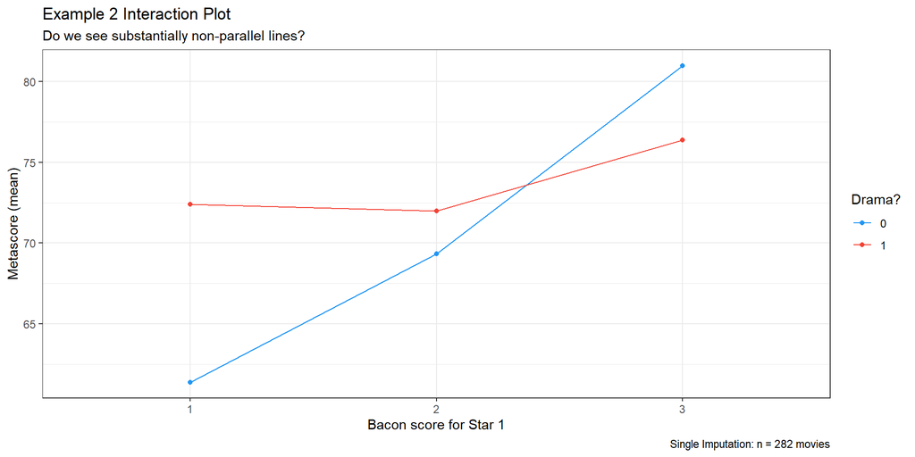

## Example 2: Two-Way ANOVA models

```r
mainfx2 <- lm(metascore ~ bacon_s1 + drama, data = mov_i3)
withint2 <- lm(metascore ~ bacon_s1 * drama, data = mov_i3)

compare_performance(mainfx2, withint2, rank = TRUE)
```

```
# Comparison of Model Performance Indices

Name     | Model |    R2 | R2 (adj.) |   RMSE |  Sigma | AIC weights
--------------------------------------------------------------------
withint2 |    lm | 0.048 |     0.031 | 15.697 | 15.866 |       0.520
mainfx2  |    lm | 0.034 |     0.024 | 15.813 | 15.926 |       0.480

Name     | AICc weights | BIC weights | Performance-Score
---------------------------------------------------------
withint2 |        0.496 |       0.028 |            71.43%
mainfx2  |        0.504 |       0.972 |            28.57%
```

## Plotting Performance Indices

```r
plot(compare_performance(mainfx2, withint2))
```

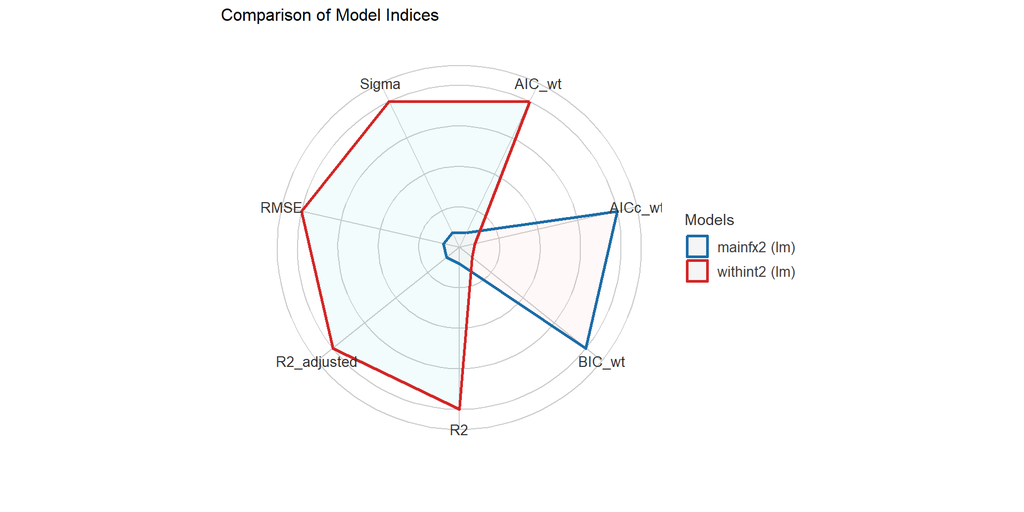

## Interpret `mainfx2` estimates?

```r
model_parameters(mainfx2, ci = 0.90, pretty_names = FALSE)
```

```
Parameter   | Coefficient |   SE |         90% CI | t(278) |      p
-------------------------------------------------------------------
(Intercept) |       65.39 | 2.29 | [61.60, 69.18] |  28.49 | < .001
bacon_s12   |        2.98 | 2.28 | [-0.77,  6.74] |   1.31 | 0.191
bacon_s13   |        8.15 | 4.27 | [ 1.11, 15.19] |   1.91 | 0.057
drama1      |        4.35 | 1.95 | [ 1.14,  7.56] |   2.23 | 0.026
```

$$metascore = 65.39 + 2.98 (Bacon = 2) + 8.15 (Bacon = 3) \\
+ 4.35 (drama = 1)$$

## Making Predictions with `mainfx2`

```r
estimate_relation(mainfx2, ci = 0.90)
```

```
Model-based Predictions

bacon_s1 | drama | Predicted |   SE |         90% CI
----------------------------------------------------
1        | 0     |     65.39 | 2.29 | [61.60, 69.18]
2        | 0     |     68.37 | 1.58 | [65.77, 70.98]
3        | 0     |     73.54 | 4.09 | [66.79, 80.29]
1        | 1     |     69.74 | 2.12 | [66.24, 73.24]
2        | 1     |     72.72 | 1.41 | [70.40, 75.05]
3        | 1     |     77.89 | 3.77 | [71.67, 84.11]

Variable predicted: metascore
Predictors modulated: bacon_s1, drama
```

## Specify `withint2` equation?

```r
model_parameters(withint2, ci = 0.90, pretty_names = FALSE)
```

```
Parameter        | Coefficient |    SE |          90% CI | t(276) |      p
--------------------------------------------------------------------------
(Intercept)      |       61.38 |  3.11 | [ 56.25, 66.52] |  19.73 | < .001
bacon_s12        |        7.94 |  3.55 | [  2.08, 13.80] |   2.24 | 0.026
bacon_s13        |       19.62 |  9.67 | [  3.65, 35.58] |   2.03 | 0.044
drama1           |       11.03 |  4.02 | [  4.40, 17.66] |   2.74 | 0.006
bacon_s12:drama1 |       -8.35 |  4.61 | [-15.97, -0.74] |  -1.81 | 0.071
bacon_s13:drama1 |      -15.63 | 10.81 | [-33.46,  2.21] |  -1.45 | 0.149
```

## Making Predictions with `withint2`

```r
estimate_relation(withint2, ci = 0.90)
```

```
Model-based Predictions

bacon_s1 | drama | Predicted |   SE |         90% CI
----------------------------------------------------
1        | 0     |     61.38 | 3.11 | [56.25, 66.52]
2        | 0     |     69.33 | 1.71 | [66.50, 72.15]
3        | 0     |     81.00 | 9.16 | [65.88, 96.12]
1        | 1     |     72.41 | 2.54 | [68.22, 76.60]
2        | 1     |     72.00 | 1.49 | [69.54, 74.46]
3        | 1     |     76.40 | 4.10 | [69.64, 83.16]

Variable predicted: metascore
Predictors modulated: bacon_s1, drama
```

## ANOVA for `mainfx2` model

```r
anova(mainfx2)
```

```
Analysis of Variance Table

Response: metascore
           Df Sum Sq Mean Sq F value  Pr(>F)
bacon_s1    2   1227  613.72  2.4196 0.09083 .
drama       1   1266 1266.03  4.9914 0.02627 *
Residuals 278  70513  253.64
---
Signif. codes:  0 '***' 0.001 '**' 0.01 '*' 0.05 '.' 0.1 ' ' 1
```

## % of Total SS explained by the two factors?

```r
eta_squared(anova(mainfx2))
```

```
# Effect Size for ANOVA (Type I)

Parameter | Eta2 (partial) |       95% CI
-----------------------------------------
bacon_s1  |           0.02 | [0.00, 1.00]
drama     |           0.02 | [0.00, 1.00]

- One-sided CIs: upper bound fixed at [1.00].
```

## ANOVA table for interaction model

```r
anova(withint2)
```

```
Analysis of Variance Table

Response: metascore
                Df Sum Sq Mean Sq F value  Pr(>F)
bacon_s1         2   1227  613.72  2.4379 0.08922 .
drama            1   1266 1266.03  5.0291 0.02572 *
bacon_s1:drama   2   1033  516.28  2.0509 0.13058
Residuals      276  69480  251.74
---
Signif. codes:  0 '***' 0.001 '**' 0.01 '*' 0.05 '.' 0.1 ' ' 1
```

## % of Total SS explained by the factors?

```r
eta_squared(anova(withint2))
```

```
# Effect Size for ANOVA (Type I)

Parameter      | Eta2 (partial) |       95% CI
----------------------------------------------
bacon_s1       |           0.02 | [0.00, 1.00]
drama          |           0.02 | [0.00, 1.00]
bacon_s1:drama |           0.01 | [0.00, 1.00]

- One-sided CIs: upper bound fixed at [1.00].
```

## Checking model `mainfx2`

```r
set.seed(20264315)
check_model(mainfx2, check = c("pp_check", "qq"), detrend = FALSE)
```

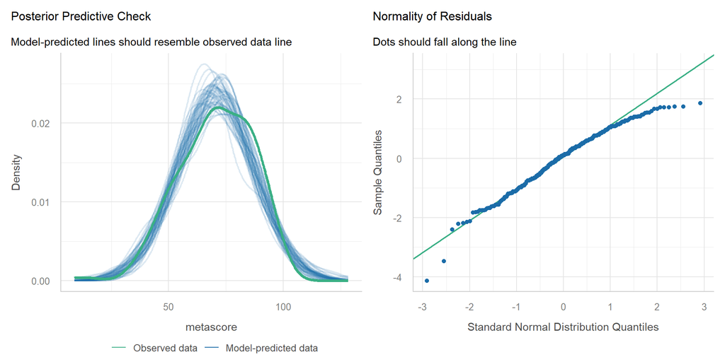

## Checking model `withint2`

```r
set.seed(20264316)
check_model(withint2, check = c("pp_check", "qq"), detrend = FALSE)
```

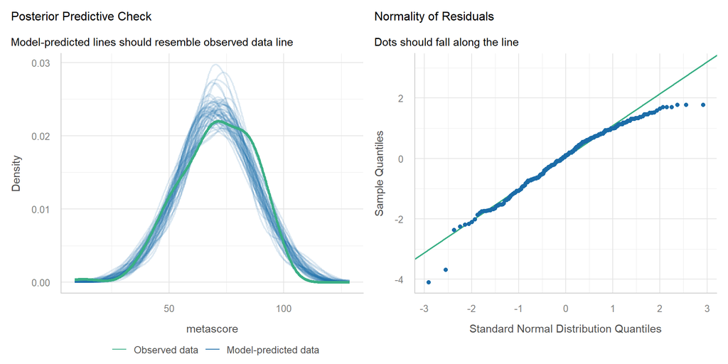

## Substantial interaction here?

- Interaction plot shows substantially non-parallel lines.
- Interaction term explains about 1% of the variation in `metascore`, overall.
- p value for the interaction term: ($p$ = 0.13)
- Substantial improvement in the fit with interaction?
  - 5/7 in-sample performance indices prefer interaction

What do you think?

## Treating Bacon number as quantitative?

We make a lot of little decisions. Are our conclusions robust?

```r
mov_i3_extra <- mov_i3 |> mutate(bacon = as.numeric(bacon_s1))

anova(lm(metascore ~ drama * bacon, data = mov_i3_extra))
```

```
Analysis of Variance Table

Response: metascore
             Df Sum Sq Mean Sq F value  Pr(>F)
drama         1   1477 1476.51  5.8895 0.01587 *
bacon         1    965  965.33  3.8506 0.05073 .
drama:bacon   1    870  869.68  3.4690 0.06358 .
Residuals   278  69695  250.70
---
Signif. codes:  0 '***' 0.001 '**' 0.01 '*' 0.05 '.' 0.1 ' ' 1
```

## Example 3

What if we add `rt_audience` as a covariate?

- We might consider centering `rt_audience`.
- Here is an **analysis of covariance** model.

```r
fit3 <- lm(metascore ~ drama * bacon_s1 + center(rt_audience),
           data = mov_i3)
```

## Our ANCOVA model `fit3`

```r
anova(fit3)
```

```
Analysis of Variance Table

Response: metascore
                     Df Sum Sq Mean Sq F value    Pr(>F)
drama                 1   1477  1476.5  7.6545  0.006047 **
bacon_s1              2   1017   508.5  2.6361  0.073452 .
center(rt_audience)   1  17162 17162.2 88.9728 < 2.2e-16 ***
drama:bacon_s1        2    305   152.4  0.7903  0.454754
Residuals           275  53046   192.9
---
Signif. codes:  0 '***' 0.001 '**' 0.01 '*' 0.05 '.' 0.1 ' ' 1
```

## Variation explained by this model?

```r
eta_squared(fit3)
```

```
# Effect Size for ANOVA (Type I)

Parameter           | Eta2 (partial) |       95% CI
---------------------------------------------------
drama               |           0.03 | [0.00, 1.00]
bacon_s1            |           0.02 | [0.00, 1.00]
center(rt_audience) |           0.24 | [0.18, 1.00]
drama:bacon_s1      |       5.71e-03 | [0.00, 1.00]

- One-sided CIs: upper bound fixed at [1.00].
```

## Drop Interaction Term?

```r
fit3_noint <- lm(metascore ~ drama + bacon_s1 + center(rt_audience),
             data = mov_i3)

anova(fit3_noint)
```

```
Analysis of Variance Table

Response: metascore
                     Df Sum Sq Mean Sq F value    Pr(>F)
drama                 1   1477  1476.5  7.6661  0.006006 **
bacon_s1              2   1017   508.5  2.6401  0.073151 .
center(rt_audience)   1  17162 17162.2 89.1077 < 2.2e-16 ***
Residuals           277  53350   192.6
---
Signif. codes:  0 '***' 0.001 '**' 0.01 '*' 0.05 '.' 0.1 ' ' 1
```

## Compare three models?

```r
compare_performance(withint2, fit3, fit3_noint, rank = TRUE)
```

```
# Comparison of Model Performance Indices

Name       | Model |    R2 | R2 (adj.) |   RMSE |  Sigma | AIC weights
----------------------------------------------------------------------
fit3_noint |    lm | 0.269 |     0.259 | 13.754 | 13.878 |       0.767
fit3       |    lm | 0.273 |     0.258 | 13.715 | 13.889 |       0.233
withint2   |    lm | 0.048 |     0.031 | 15.697 | 15.866 |    1.88e-17

Name       | AICc weights | BIC weights | Performance-Score
-----------------------------------------------------------
fit3_noint |        0.786 |       0.992 |            99.45%
fit3       |        0.214 |       0.008 |            65.33%
withint2   |     1.83e-17 |    3.94e-18 |             0.00%
```

## Compare performance plot?

```r
plot(compare_performance(withint2, fit3, fit3_noint))
```

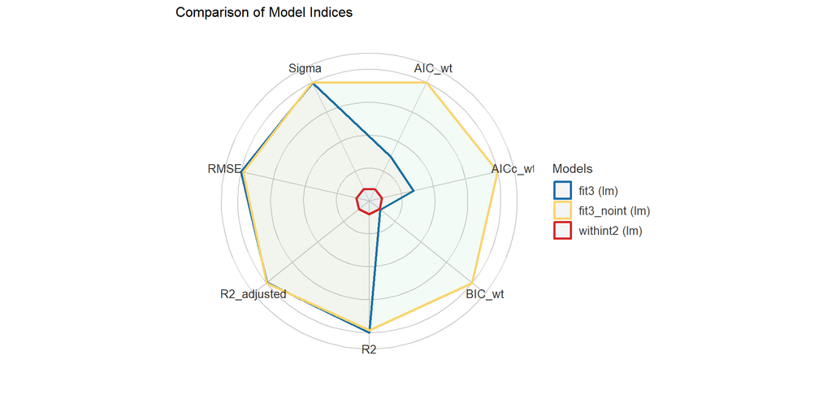

## Check model `fit3` (1/3)

```r
check_model(fit3, check = c("pp_check", "qq"), detrend = FALSE)
```

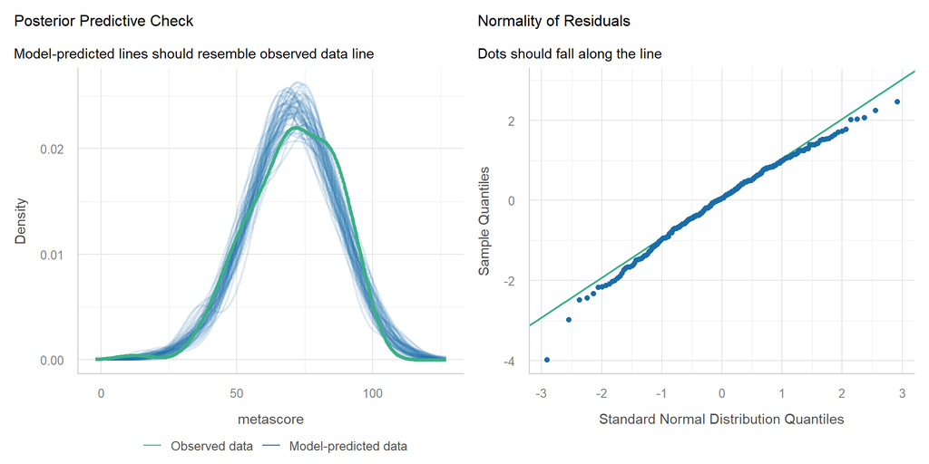

## Check model `fit3` (2/3)

```r
check_model(fit3, check = c("linearity", "homogeneity"))
```

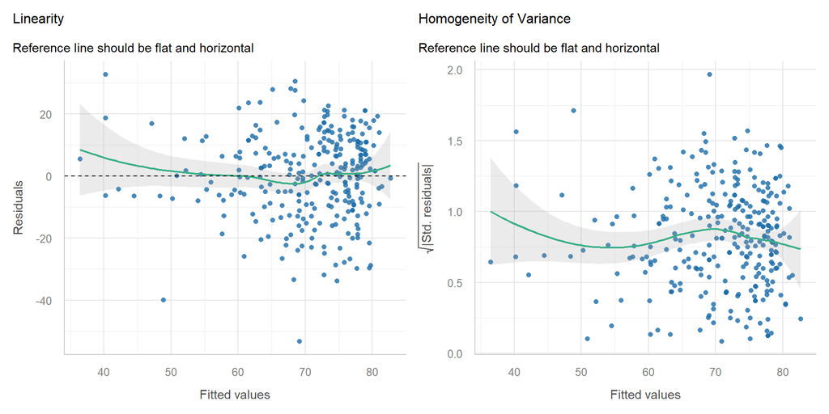

## Check model `fit3` (3/3)

```r
check_model(fit3, check = c("outliers", "vif"))
```

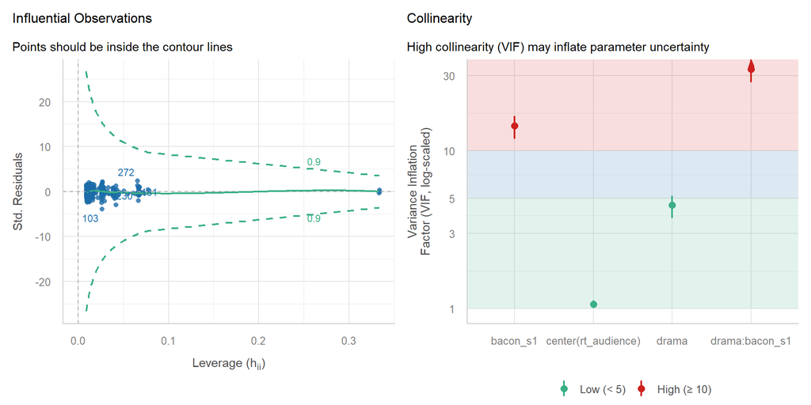

## Next Time

- Our first attempt at a general strategy for regression model building and assessment.
- A data set containing 500 adults living with diabetes.